# Comprensión del Negocio y de los Datos

Proyecto Final

Alfredo Lefranc Flores, Cynthia Raquel Valdivia Tirado, Rafael Sandoval Fernández, Marco Antonio Ramos Juárez y Francisco Velazquez Guadarrama

2021

## Planteamiento del Problema

Al conectar una multiplicidad de orígenes y destinos, el transporte público ha probado ser un motor del desarrollo económico urbano, además de potencialmente impactar los ámbitos de salud y seguridad pública, congestión vehicular, y la inclusión social. En este contexto, los sistemas de bicicletas compartidas han ofrecido una alternativa a las opciones de transporte en redes urbanas altamente complejas. Como tal, cualquier empresa de bicicletas compartidas debe ser capaz de ofrecer a sus usuarios una opción eficaz para trasladarse, es decir, práctica y accesible. La empresa Wheelie Wonka no debe ser la excepción.

Sin embargo, tal como es el caso de los flujos de tráfico, las bicicletas enfrentan el problema de demandas asimétricas en tiempo y espacio. Esto puede significar un problema en la medida en que la infraestructura de la red de bicicletas limite a los usuarios en momentos de alta demanda, y también que el uso y desplazamiento de las bicicletas en un momento dado no corresponda a las necesidades de los usuarios siguientes, creando excesos de oferta y de demanda en distintas zonas de Boston.

En Boston, para el servicio de bicicletas compartidas, existen estaciones designadas para su almacenamiento, por lo que la estación podría estar vacía o saturada en diferentes periodos. Los operadores de bicicletas compartidas generalmente redistribuyen las bicicletas entre las diferentes estaciones; no obstante, esta distribución desequilibrada puede conllevar a pérdidas para la empresa, al estar utilizando recursos humanos innecesarios, y perjudicar a los usuarios en su acceso al servicio, dado que podría generarse una situación de falta de disponibilidad de bicicletas o a la saturación de éstas. Por lo tanto, predecir un número exacto de bicicletas disponibles en las estaciones es importante.

Existen factores que pueden incidir en las tendencias de los viajes de los pasajeros que son relevantes para determinar la disponibilidad de las bicicletas, como la duración del viaje, la hora del día (horas punta), el día de la semana, el clima, la edad del pasajero, su género, las estaciones del año, las vacaciones, la popularidad de la ubicación, entre otros. Por tanto, mejores datos podrían ayudar a hacer una mejor predicción.

En este contexto, la ciencia de datos ofrece una solución muy atractiva. Mediante el análisis computacional del uso de las bicicletas, es posible reconocer patrones y predecir la disponibilidad de bicicletas en un lugar y momento específicos. Esto puede ayudar a la empresa Wheelie Wonka en dos sentidos.

1. Proveer al usuario de información con la cual pueda tomar decisiones óptimas de transporte.
2. Poder hacer ajustes en la distribución de las bicicletas a lo largo de las cicloestaciones para prevenir escaseces y excesos en el sistema.

Estos puntos seguramente aumentarían la satisfacción del usuario, disminuirían las pérdidas en eficiencia, y permitirían un mayor uso del servicio, lo cual sólo podría traer beneficios a Wheelie Wonka.

En este sentido, los objetivos específicos de este proyecto son los siguientes:

1. Poder pronosticar la duración de los viajes.
2. Entender los factores que tienen un impacto en la duración de los viajes e identificar patrones geográficos en los datos.
3. Estimar el número de bicicletas por estación en ventanas de 10 minutos.

Estos tres puntos se verán reflejados en nuestro entregable final, el producto para los clientes: un dashboard que modele el flujo de bicicletas en las estaciones para un día de la semana dado, en intervalos de 10 minutos.

Consideraremos nuestras predicciones como buenas a partir de que generen valor para la empresa. Esto es, la predicción debe ser útil al usuario para tomar sus decisiones de transporte casi en tiempo real, y también debe permitir al negocio monitorear de manera realista los flujos de bicicletas en Boston y las cicloestaciones.

## Comprensión de los Datos

En lo que resta de este documento analizamos los datos, y los preparamos para el modelado. Primero hacemos una exploración inicial de las bases y de valores faltantes. Asimismo, generamos variables útiles a partir de las ya existentes. Una vez hecho esto, mostramos nuestros principales hallazgos del análisis exploratorio de los datos. Por último, realizamos transformaciones finales e integramos una base final para pasar a los modelos.

Empezamos por cargar los datos.

Buscamos NAs en las variables para poder tomar decisiones al respecto.

```r
# asignar NAs a valores vacíos de measurement_flag
weather$Measurement_Flag[weather$Measurement_Flag==" "] <- NA

# función para NAs
check_nas <- function(df){
  df %>%
    select_if(~sum(is.na(.)) > 0) %>%
    miss_var_summary()
}

# tabla resumen de missing values: trips
kable(check_nas(trips), booktabs=T, align = 'c',
      col.names = c("Variable", "Cantidad","%"), digits = 4, caption = "trips") %>%
  kable_styling(position = "center", latex_options="HOLD_position")
```

trips

| Variable | Cantidad | % |
| --- | --- | --- |
| birth_date | 1228381 | 77.7936 |
| end_statn | 45 | 0.0028 |
| strt_statn | 14 | 0.0009 |

```r
# tabla resumen de missing values: weather
kable(check_nas(weather), booktabs=T, align = 'c',
      col.names = c("Variable", "Cantidad","%"), digits = 4, caption = "weather") %>%
  kable_styling(position = "center", latex_options="HOLD_position")
```

weather

| Variable | Cantidad | % |
| --- | --- | --- |
| Quality_Flag | 2654 | 100.0000 |
| Measurement_Flag | 1387 | 52.2607 |

#### Análisis para imputación de estaciones

```r
prcnt_sameStation <- trunc(sum(trips$strt_statn == trips$end_statn,
                               na.rm = T) / nrow(trips) * 100 * 100)/100
NA_either <- sum(is.na(trips$strt_statn) | is.na(trips$end_statn))
```

Se decide eliminar la variable “Quality_Flag”, pues esta contiene únicamente NAs.

```r
weather$Quality_Flag <- NULL
#weather$Measurement_Flag <- NULL
trips <- trips[!is.na(trips$strt_statn) & !is.na(trips$end_statn), ]
```

Nótese que la información contenida en “birth_date” no es directamente útil, pues se tienen observaciones de distintos años. La información que seguramente será muy relevante es la edad del usuario cuando hizo uso del servicio, no su edad actual. Por ello, para poder analizar la variable “birth_date” y tomar una decisión respecto a sus NA, primero se procesa las variables “start_date”, “end_date”, y finalmente se genera una variable con la edad a partir de “birth_date”. Asimismo, se procesan las fechas en la base del clima para extraer una fecha y hora utilizables. Todo esto con la finalidad de poder realizar un análisis exploratorio que posteriormente permita tomar una decisión.

```r
# Se divide start_date en fecha y hora para extraer la información
colnames(trips)[colnames(trips) == 'start_date'] <- 'start_DateTime'
startDateTime <- strsplit(trips$start_DateTime, ' ')

startDate <- sapply(startDateTime, "[", 1)
trips$start_date <- as.Date(startDate, '%m/%d/%Y') %>% date()
trips$start_year <- trips$start_date %>% year()
trips$start_month <- trips$start_date %>% month()
trips$start_weekday <- weekdays(trips$start_date)

startTime <- sapply(startDateTime, "[", 2)
trips$start_hour <- as.POSIXct(startTime,format="%H:%M:%S") %>%
  hour()
trips$start_minute <- format(as.POSIXct(startTime,format="%H:%M:%S"),"%M")


# Se divide end_date en fecha y hora para extraer la información (poder utilizarla posteriormente)
colnames(trips)[colnames(trips) == 'end_date'] <- 'end_DateTime'
endDateTime <- strsplit(trips$end_DateTime, ' ')

endDate <- sapply(endDateTime, "[", 1)
trips$end_date <- as.Date(endDate, '%m/%d/%Y')
trips$end_year <- format(trips$end_date, '%Y')
trips$end_month <- format(trips$end_date, '%m')
trips$end_weekday <- weekdays(trips$end_date)

endTime <- sapply(endDateTime, "[", 2)
trips$end_hour <- format(as.POSIXct(endTime,format="%H:%M:%S"),"%H")
trips$end_minute <- format(as.POSIXct(endTime,format="%H:%M:%S"),"%M")

# Se genera la edad del usuario al empezar con el servicio
trips$age <- as.integer(trips$start_year) - trips$birth_date

# se hace lo mismo para sacar fecha y hora en la base de clima
weather$start_date <- weather$DATE %>% strsplit(' ') %>%
  sapply("[", 1) %>% as.Date('%Y%m%d') %>% date()

weather$start_hour <- weather$DATE %>% strsplit(' ') %>%
  sapply("[", 2) %>% as.POSIXct(format="%H:%M") %>%
  hour()

# remover objetos grandes
rm(endDateTime,startDateTime,endDate,endTime,startDate,startTime)
```

#### Unión de base de clima con viajes

Usando un razonamiento similar, se considera que, en general, el hecho de que haya llovido durante el día puede también decirnos algo de información relativamente distinta. Por un lado, si había llovido antes de tomar una bicicleta, esto podría tener un efecto en las decisiones de los usuarios a través de sus ánimos y la expectativa del clima para el resto del día. Por otro, si aún no había llovido, es altamente probable que los usuarios hayan elegido iniciar un viaje con base en sus propias predicciones respecto al clima para el resto del día con base en factores que, para efectos de nuestros datos, no son observables. Es por ello que también se crea una variable que nos informa si llovió o no en un determinado día.

```r
# Imputación a los NA para HPCP en la base trips
weather$start_hour <- as.integer(weather$start_hour)
unique_dates <- unique(trips$start_date)
weather_calendar <- as.data.frame(matrix(NA, nrow = length(unique_dates), ncol = 25))
colnames(weather_calendar) <- c('start_date', 0:23)
weather_calendar$start_date <- unique_dates
for ( i in 1:nrow(weather_calendar) ) {
  curr_date <- weather_calendar$start_date[i]
  ss_by_date <- weather[weather$start_date == curr_date, c('start_hour', 'HPCP')]
  if (nrow(ss_by_date) > 0) {
    aux <- 3
    for ( j in 0:22 ) {
      ss_by_hr <- ss_by_date[ss_by_date$start_hour >= (j-3+aux) & ss_by_date$start_hour <= (j+1),
                             c('start_hour', 'HPCP')]
      est_weather <- sum(ss_by_hr$HPCP, na.rm=T) / 5
      if (nrow(ss_by_hr) > 0) {
        weather_calendar[i, j+2] <- est_weather
      }
      true_weather <- ss_by_date[ss_by_date$start_hour == j, c('start_hour', 'HPCP')]
      if (nrow(true_weather) > 0) {
        weather_calendar[i, j+2] <- max(true_weather$HPCP[1], est_weather)
      }
      aux <- max(aux - 1,0)
    }
    # La hora 23, inalcanzable en el loop anterior
    ss_by_hr <- ss_by_date[ss_by_date$start_hour >= (23-3) & ss_by_date$start_hour <= (23),
                           c('start_hour', 'HPCP')]
    est_weather <- sum(ss_by_hr$HPCP, na.rm=T) / 5
    if (nrow(ss_by_hr) > 0) {
        weather_calendar[i, 23+2] <- est_weather
    }
    true_weather <- ss_by_date[ss_by_date$start_hour == 23, c('start_hour', 'HPCP')]
    if (nrow(true_weather) > 0) {
      weather_calendar[i, 23+2] <- max(true_weather$HPCP[1], est_weather)
      }
  }
}

date_matcher <- melt(weather_calendar, id.var = 'start_date', variable.name = 'start_hour')
date_matcher$start_hour <- as.integer(date_matcher$start_hour)
colnames(date_matcher)[3] <- 'HPCP'
trips <- merge(trips, date_matcher, by=c("start_date", "start_hour"), all.x=T)


# Creación de la variable indicadora de día lluvioso
rained_matcher <- aggregate(HPCP~start_date, data=weather, FUN=sum, na.action = na.omit)
rained_matcher$rained <- ifelse(rained_matcher$HPCP>0, 1, 0)
trips <- merge(trips, rained_matcher[,c('start_date', 'rained')], by='start_date', all.x=T)

HPCP_NAs_prcnt <- trunc(mean(is.na(trips$HPCP))*100*100)/100
# Porcentaje de NAs en HPCP

rained_NAs_prcnt <- trunc(mean(is.na(trips$rained))*100*100)/100
# Porcentaje de NAs en rained

# Se forman intervalos para el nivel de lluvia
trips$HPCP <- cut(trips$HPCP,
                  breaks=c(-0.001, seq(0,0.09,.015), seq(0.1,0.25,0.025),0.35,0.5,0.7,1.5),
                  labels=c(0, seq(0,0.09,.015)[-1], seq(0.1,0.25,0.025),0.35,0.5,0.7,1.5))


# Se asigna SR a las NA para poder trabajar como factor
trips[is.na(trips$rained), 'rained'] <- 'SR'
trips$HPCP = factor(trips$HPCP, levels=c(levels(trips$HPCP), 'SR'))
trips$HPCP[is.na(trips$HPCP)] = 'SR'


# Transformamos a numéricas la variable de lluvia
#HPCP 2
trips$hpcp2 <- 0
trips$hpcp2[trips$HPCP=="SR"] <- 1
summary(trips$hpcp2)
```

```
   Min. 1st Qu.  Median    Mean 3rd Qu.    Max.
 0.0000  1.0000  1.0000  0.8881  1.0000  1.0000
```

```r
# HPCP numerica
trips$HPCP[trips$HPCP=="SR"] <- 0
trips$HPCP <- trips$HPCP %>% as.character %>% as.numeric

# Se transforman a factor
trips$rained <- trips$rained %>% as.factor
```

También se asigna `Measurement_Flag`.

```r
trips <- merge(trips, weather[,c('start_date','start_hour', 'Measurement_Flag')],
               by = c('start_date','start_hour'), all.x = T)

trips$Measurement_Flag[is.na(trips$Measurement_Flag)] <- "unknown"
```

Para concluir el análisis inicial, transformamos las variables.

```r
# categóricas
trips$subsc_type <- trips$subsc_type %>% as.factor
trips$gender <- trips$gender %>% as.factor
trips$status <- trips$status %>% as.factor
trips$bike_nr <- trips$bike_nr %>% as.factor
trips$zip_code <- trips$zip_code %>% as.factor
trips$Measurement_Flag <- trips$Measurement_Flag %>% as.factor

trips$start_year <- trips$start_year %>% as.factor
trips$end_year <- trips$end_year %>% as.factor
trips$start_month <- trips$start_month %>% as.factor
trips$end_month <- trips$end_month %>% as.factor
trips$start_weekday <- trips$start_weekday %>% as.factor
trips$end_weekday <- trips$end_weekday %>% as.factor

trips$strt_statn <- trips$strt_statn %>% as.factor
trips$end_statn <- trips$end_statn %>% as.factor

# numéricas
trips$start_hour <- trips$start_hour %>% as.integer
trips$end_hour <- trips$end_hour %>% as.integer
trips$start_minute <- trips$start_minute %>% as.integer
trips$end_minute <- trips$end_minute %>% as.integer

summary(trips)
```

```
   start_date           start_hour        seq_id          hubway_id
 Min.   :2011-07-28   Min.   : 0.00   Min.   :      1   Min.   :      8
 1st Qu.:2012-08-07   1st Qu.:10.00   1st Qu.: 394767   1st Qu.: 446536
 Median :2013-05-16   Median :15.00   Median : 789539   Median : 895070
 Mean   :2013-02-02   Mean   :13.87   Mean   : 789529   Mean   : 886549
 3rd Qu.:2013-08-22   3rd Qu.:18.00   3rd Qu.:1184282   3rd Qu.:1328096
 Max.   :2013-11-30   Max.   :23.00   Max.   :1579025   Max.   :1748022

    status           duration        start_DateTime       strt_statn
 Closed:1578973   Min.   :   -6900   Length:1578973     22     :  56442
                  1st Qu.:     412   Class :character   36     :  42568
                  Median :     660   Mode  :character   53     :  35438
                  Mean   :    1150                      67     :  33685
                  3rd Qu.:    1082                      16     :  32859
                  Max.   :11994458                      42     :  32795
                                                        (Other):1345186
 end_DateTime         end_statn          bike_nr             subsc_type
 Length:1578973     22     :  56280   B00490 :   2138   Casual    : 472592
 Class :character   36     :  43387   B00268 :   2124   Registered:1106381
 Mode  :character   42     :  34916   B00548 :   2112
                    67     :  34580   B00559 :   2091
                    53     :  33369   B00563 :   2080
                    33     :  32246   B00391 :   2072
                    (Other):1344195   (Other):1566356
    zip_code        birth_date         gender       start_year
        :472747   Min.   :1932            :472592   2011:140505
 '02118 :121748   1st Qu.:1969      Female:271693   2012:533793
 '02139 : 89437   Median :1979      Male  :834688   2013:904675
 '02215 : 86757   Mean   :1976
 '02116 : 77279   3rd Qu.:1985
 '02115 : 57522   Max.   :1995
 (Other):673483   NA's   :1228358
  start_month       start_weekday     start_minute      end_date
 8      :270602   domingo  :196016   Min.   : 0.00   Min.   :2011-07-28
 9      :263700   jueves   :234831   1st Qu.:14.00   1st Qu.:2012-08-07
 10     :253156   lunes    :230405   Median :29.00   Median :2013-05-16
 7      :205296   martes   :231813   Mean   :29.46   Mean   :2013-02-02
 6      :165366   miércoles:238791   3rd Qu.:44.00   3rd Qu.:2013-08-22
 5      :152138   sábado   :215784   Max.   :59.00   Max.   :2013-12-01
 (Other):268715   viernes  :231333
```

[output cut: 8 more lines]

```
   end_minute         age               HPCP          rained
 Min.   : 0.00   Min.   :17.0      Min.   :0.000000   0 : 159616
 1st Qu.:15.00   1st Qu.:27.0      1st Qu.:0.000000   1 : 315362
 Median :30.00   Median :32.0      Median :0.000000   SR:1103995
 Mean   :29.72   Mean   :35.5      Mean   :0.002609
 3rd Qu.:45.00   3rd Qu.:43.0      3rd Qu.:0.000000
 Max.   :59.00   Max.   :79.0      Max.   :1.500000
                 NA's   :1228358
     hpcp2        Measurement_Flag
 Min.   :0.0000   g      :    219
 1st Qu.:1.0000   T      :  56199
 Median :1.0000   unknown:1522555
 Mean   :0.8881
 3rd Qu.:1.0000
 Max.   :1.0000
```

## EDA

### Exploración georreferenciada

Antes de realizar un análisis estadístico, para poder desarrollar una mejor intuición visual sobre las rutas más frecuentes hemos creado un dashboard donde se grafican georrefernciadamente 1000 viajes aleatorios de la base de datos. En el dashboard se dimensiona la importancia de cada estación. Además, se puede explorar con grado de detalle cada estación y obtener información sobre sus rutas más frecuentes y menos frecuentes.

[figure not shown]

Mapa del centro de Boston.

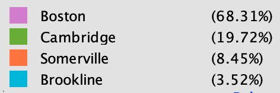

Leyenda para el dashboard.

Bievenido a nuestra herramienta interactiva de visualización de viajes en bicicleta en Boston. Aquí puede explorar los viajes más frecuentes y conocer más acerca de las dinámicas de movilidadn de la ciudad.

Lo primero que notamos es que la gran mayoría de los viajes son rosas, es decir dentro de la municipalidad de Bostón, relativamente pocos viajes ocurren fuera. Asimismo, el epicentro de la movilidad son las estaciones cercanas a la pequeña peninsula de Boston. Asimismo, el segundo componente de estaciones más conectado es Cambridge y el tercero es Somerville.

En la herramienta siguiente se puede explorar los viajes más frecuentes estación por estación. En la siguiente visualización se muestran solamente 1,000 viajes aleatorios de toda la muestra de datos,

[en esta visualización](https://marcoyel21.github.io/gephi_vis/network/)

### Análisis estadístico

Una vez construidas las variables temporales, procedemos a hacer el análisis exploratorio de los datos, teniendo en mente que la variable objetivo es la duración de los viajes.

#### Análisis univariado

Primero, revisamos la distribución de las variables. Graficamos histogramas para las variables continuas y gráficas de barras para las categóricas.

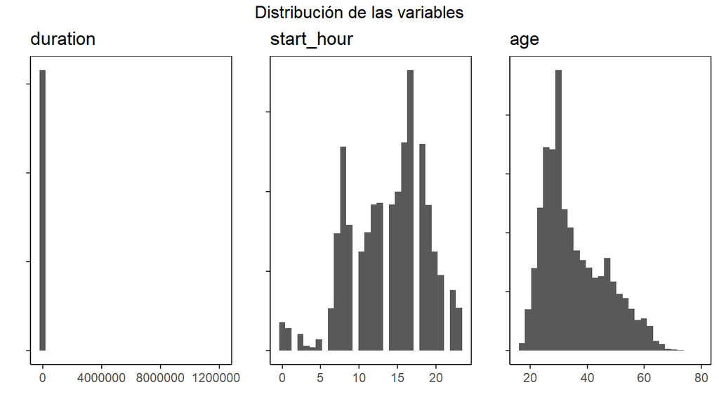

```r
# histograma para variables continuas
myhist <- function(yvar){
  ggplot(trips, aes_(x=as.name(yvar), fill=as.name(yvar)))+
    geom_histogram()+
    ggtitle(paste0(as.name(yvar)))+
    xlab("")+
    ylab("")+ geom_rangeframe()+
    theme_bw()+
    theme(axis.line = element_line(colour = "black"),
          axis.text.y = element_blank(),
          panel.grid.major = element_blank(),
          panel.grid.minor = element_blank(),
          panel.background = element_blank(),
          legend.position = 'none')
}

hists<- trips %>%
  select(
    duration,
    start_hour,
    age
  ) %>%
  names() %>%
  lapply(myhist)

# grafico las variables
grid.arrange(grobs=hists,ncol=3,
             top=textGrob("Distribución de las variables"))
```

En esta gráfica es claro que hay presencia de outliers en la variable de duración. Esto podría deberse a errores en el registro, y podría afectar nuestras predicciones. Más adelante se toma una decisión al respecto.

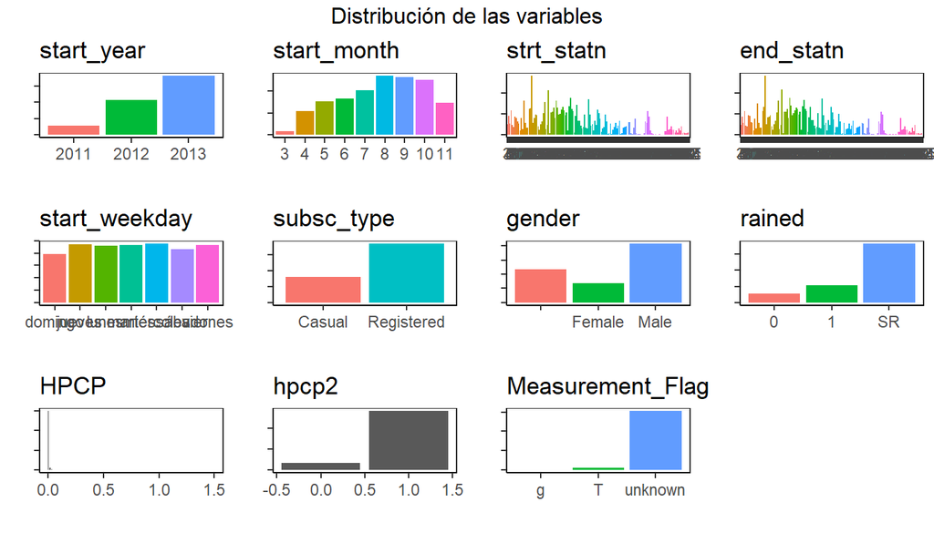

```r
# barras para las categóricas
# histograma para variables continuas
mybar <- function(yvar){
  ggplot(trips, aes_(x=as.name(yvar), fill=as.name(yvar)))+
    geom_bar()+
    ggtitle(paste0(as.name(yvar)))+
    xlab("")+
    ylab("")+ geom_rangeframe()+
    theme_bw()+
    theme(axis.line = element_line(colour = "black"),
          axis.text.y = element_blank(),
          panel.grid.major = element_blank(),
          panel.grid.minor = element_blank(),
          panel.background = element_blank(),
          legend.position = 'none')
}

bars <- trips %>%
  select(
    start_year,
    start_month,
    strt_statn,
    end_statn,
    start_weekday,
    subsc_type,
    gender,
    rained,
    HPCP,
    hpcp2,
    Measurement_Flag
  ) %>%
  names() %>%
  lapply(mybar)

# grafico las variables
grid.arrange(grobs=bars,ncol=4,
             top=textGrob("Distribución de las variables"))
```

Aquí podemos notar que los viajes están uniformemente distribuidos a lo largo de los días de la semana, aunque dominan los viajes del 2013 y del mes de agosto, sin haber observaciones en los meses de invierno. Por otra parte, la varianza entre uso de estaciones es notable.

## Análisis bivariado

Ahora procedemos a explorar relaciones entre los usuarios y la duración, en particular la edad y el género.

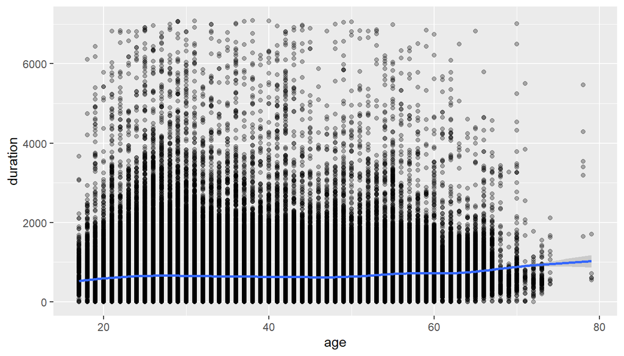

```r
# Se muestra la relación entre edad y duración (acotada superiormente por su percentil 99%)
ggplot(trips, aes(age, duration)) +
  geom_point(alpha=0.3) +
  geom_smooth() +
  ylim(0, quantile(trips$duration, probs=0.99))
```

```r
corr_age_duration <- cor(trips$age, trips$duration, use = "complete.obs")
```

A pesar de una gran variación tanto en duración como edad, la correlación entre éstas es prácticamente nula.

Podemos notar que predominan los usuarios hombres, sobre todo a partir de los 30, donde la frecuencia de uso de las mujeres cae abruptamente. En general, puede verse que el grueso de los usuarios son jóvenes.

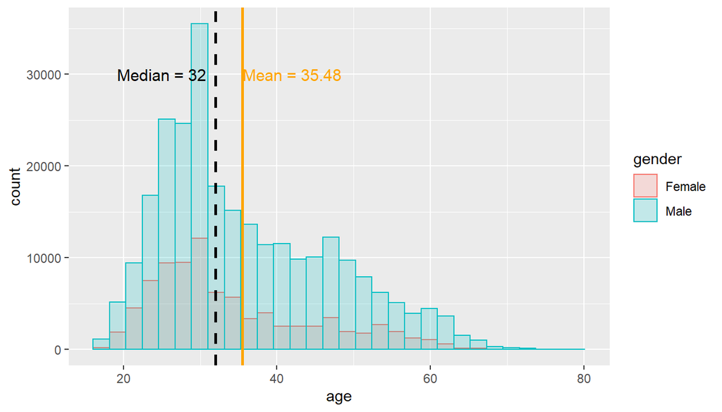

```r
# Histograma de la edad por género
ggplot(data=subset(trips, !is.na(age)), aes(x=age, color=gender, fill=gender)) +
  geom_histogram(alpha=0.2, position="identity") +
  geom_vline(aes(xintercept=mean(age, na.rm=T)), color="orange", size=1) +
  geom_vline(aes(xintercept=median(age, na.rm=T)), color="black", linetype="dashed", size=1) +
  annotate("text",                        # Add text for mean
           x = 25,
           y = 30000,
           label = paste("Median =", median(trips$age, na.rm=T)),
           col = "black",
           size = 4) +
  annotate("text",                        # Add text for mean
           x = 42,
           y = 30000,
           label = paste("Mean =", trunc(mean(trips$age, na.rm=T)*100)/100),
           col = "orange",
           size = 4)
```

Dada la distribución que sigue la edad, observada en los histogramas, se imputa la mediana a las edades.

```r
trips[is.na(trips$age), 'age'] <- median(trips$age, na.rm = T)
```

Pasando ahora la atención a las variables de “gender” y de “zip_code”, es posible notar que valores vacíos de “gender” corresponden en su totalidad a los usuarios no registrados, y sólo unos pocos adicionales (155) son usuarios registradas pero sin reportar su “zip_code”. A estos se les imputa “Unknown” y se les trata como factor.

```r
empty_gender <- sum(trips$gender=='')
empty_zipcode <- sum(trips$zip_code=='')
unregistered <- sum(trips$subsc_type!='Registered')
aux <- t(cbind(unregistered, empty_gender, empty_zipcode))
aux <- cbind(c('subsc_type','gender','zip_code'), aux, aux)
aux[,3] <- trunc(as.numeric(aux[,2])/nrow(trips)*1000000)/1000000*100
rownames(aux) <- NULL
kable(aux, col.names = c("Variable","Número de valores vacíos", "%"), align = "lrr", booktabs=T) %>%
  kable_styling(position = "center", latex_options="HOLD_position")
```

| Variable | Número de valores vacíos | % |
| --- | --- | --- |
| subsc_type | 472592 | 29.9303 |
| gender | 472592 | 29.9303 |
| zip_code | 472747 | 29.9401 |

```r
# Asigna un valor a los valores vacíos del género y zip_code.
trips$gender <- factor(trips$gender, levels=c(levels(trips$gender), 'Unknown'))
trips$gender[is.na(trips$gender)] <- 'Unknown'
trips$gender <- droplevels(trips$gender)

trips$zip_code <- factor(trips$zip_code, levels=c(levels(trips$zip_code), 'Unknown'))
trips$zip_code[is.na(trips$zip_code)] <- 'Unknown'
```

## Preparación de los Datos

```r
trips <- trips[trips$duration>0, ]
```

Ahora buscamos columnas con el mismo valor para todas las observaciones, pues de ser el caso no serían útiles para el modelo.

```r
# trips
uselessCols_trips <- c()
for (i in colnames(trips)) {
  if ( length(unique(trips[[i]]))==1 ) {
    uselessCols_trips <- c(uselessCols_trips, i)
  }
}

# stations
uselessCols_stations <- c()
for (i in colnames(stations)) {
  if ( length(unique(stations[[i]]))==1 ) {
    uselessCols_stations <- c(uselessCols_stations, i)
  }
}

# weather
uselessCols_weather <- c()
for (i in colnames(weather)) {
  if ( length(unique(weather[[i]]))==1 ) {
    uselessCols_weather <- c(uselessCols_weather, i)
  }
}
```

Notamos que la variables “status” en la base con información de los viajes contiene un único valor presente en todas las observaciones. Lo mismo sucede con “STATION”, “STATION_NAME”, “ELEVATION”, “LATITUDE” y “LONGITUDE” en la base con datos del clima. Se presentan los valores de las variables mencionadas para evaluar su utilidad.

```r
uselessCols <- c(uselessCols_trips, uselessCols_weather)
uValues <- c(unique(trips[,uselessCols_trips]), unique(weather[,uselessCols_weather]))
names(uValues) <- NULL
kable(cbind(uselessCols, uValues),
      col.names = c("Nombre de la variable","Valor único"), align = "lr", booktabs=T) %>%
  kable_styling(position = "center", latex_options="HOLD_position")
```

| Nombre de la variable | Valor único |
| --- | --- |
| status | 1 |
| STATION | COOP:190770 |
| STATION_NAME | BOSTON MA US |
| ELEVATION | 3.7 |
| LATITUDE | 42.3606 |
| LONGITUDE | -71.0106 |

Se elimina, entonces, la variable “status”, pues esta no contiene información útil.

```r
trips$status <- NULL

n_obs <- c()
for (i in unique(stations$municipal)) {
  n_obs <- c(n_obs, nrow(stations[stations$municipal==i,]))
}

kable(cbind(unique(stations$municipal), n_obs),
      col.names = c("Municipalidad","Número de estaciones"), align = "lr", booktabs=T) %>%
  kable_styling(position = "center", latex_options="HOLD_position")
```

| Municipalidad | Número de estaciones |
| --- | --- |
| Boston | 97 |
| Cambridge | 28 |
| Brookline | 5 |
| Somerville | 12 |

Se presentan finalmente algunos estadísticos relevantes sobre las variables numéricas de los viajes.

```r
# No muestro las variables de id de la estación y viaje, ni el año de nacimiento
tdf <- select_if(trips, is.numeric)
tdf <- subset(tdf, select = -c(seq_id,hubway_id))
aux <- matrix(NA, ncol = 8, nrow = 9) # Si no corre, cambiar 7 por 9
k <- 1
for (i in colnames(tdf)) {
  qu <- quantile(trips[[i]], probs = c(0.05, 0.25, 0.5, 0.75, 0.95), na.rm = TRUE)
  n <- length(which(!is.na(trips[[i]])))
  NAs <- nrow(trips)-n
  mean <- format(round(mean(trips[[i]], na.rm = TRUE), digits = 4), scientific = FALSE)
  min <- min(trips[[i]],na.rm = TRUE)
  max <- max(trips[[i]], na.rm = TRUE)
  aux[k,] <- c(mean, min, qu, max)
  k <- k + 1
}
colnames(aux) <- c("Media", "Mín.", "p05", "p25", "p50", "p75", "p95", "Máx.")
rownames(aux) <- colnames(tdf)
kable(aux, booktabs=T) %>% kable_styling(position = "center", latex_options="HOLD_position")
```

|  | Media | Mín. | p05 | p25 | p50 | p75 | p95 | Máx. |
| --- | --- | --- | --- | --- | --- | --- | --- | --- |
| start_hour | 13.8683 | 0 | 6 | 10 | 15 | 18 | 21 | 23 |
| duration | 1153.173 | 1 | 188 | 418 | 660 | 1087 | 2524 | 11994458 |
| birth_date | 1976.295 | 1932 | 1955 | 1969 | 1979 | 1985 | 1990 | 1995 |
| start_minute | 29.4607 | 0 | 3 | 14 | 29 | 44 | 56 | 59 |
| end_hour | 14.042 | 0 | 6 | 10 | 15 | 18 | 21 | 23 |
| end_minute | 29.7205 | 0 | 2 | 15 | 30 | 45 | 57 | 59 |
| age | 32.775 | 17 | 26 | 32 | 32 | 32 | 44 | 79 |
| HPCP | 0.0026 | 0 | 0 | 0 | 0 | 0 | 0.015 | 1.5 |
| hpcp2 | 0.8881 | 0 | 0 | 1 | 1 | 1 | 1 | 1 |

```r
rm(tdf, hists, ss_by_date, ss_by_hr)
```

Se asignan las coordenadas de cada estación por cada arrivo y salida. Asimismo, se utilizan para calcular las distancias entre ellas.

```r
# Coordenadas
stations$strt_statn <- stations$id
stations$end_statn <- stations$id
trips <- merge(trips, stations[, c('strt_statn', 'lat','lng')], by='strt_statn', all.x=T)
colnames(trips)[colnames(trips) == 'lat'] <- 'start_lat'
colnames(trips)[colnames(trips) == 'lng'] <- 'start_lng'
trips <- merge(trips, stations[, c('end_statn', 'lat','lng')], by='end_statn', all.x=T)
colnames(trips)[colnames(trips) == 'lat'] <- 'end_lat'
colnames(trips)[colnames(trips) == 'lng'] <- 'end_lng'

# Distancias en metros
trips$distance <- distGeo(as.matrix(cbind(trips$start_lng,
                                          trips$start_lat)),
                          as.matrix(cbind(trips$end_lng, trips$end_lat)))
```

Por último, en lugar de usar el ID de la bici como una variable categórica, lo cual sería computacionalmente muy pesado ya que hay más de 1100 bicis, decidimos tomar la letra del ID como la familia de la bicicleta, o su generación, y el número de serie como proxy de la antigüedad de la bici, donde números más pequeños son bicicletas más viejas.

```r
# nuevas variables para bike nr

# numero de bicis en los datos
unique(trips$bike_nr) %>% length
```

```
[1] 1164
```

```r
# familia de la bici
trips$bike_fam <- substr((trips$bike_nr) %>% as.character(),1,1) %>%
  as.factor

# antigüedad
trips$bike_antiq <- substr(trips$bike_nr %>% as.character(),2,6) %>% as.numeric()

summary(trips$bike_antiq)
```

```
   Min. 1st Qu.  Median    Mean 3rd Qu.    Max.    NA's
      0     241     474     639    1115    7930     465
```

```r
# sustituyo la mediana para la antigüedad de las bicis sin bike nr
trips$bike_antiq[is.na(trips$bike_antiq)] <- median(
  trips$bike_antiq, na.rm=T)
```

# Base final

Una vez hecho el análisis de los datos, guardamos la base final que usaremos para los modelos de ML.

```r
#primero seleccionamos las variables
trips_filter <- trips %>%
  select(-c("hubway_id","start_DateTime","end_DateTime",
            "birth_date","end_date","end_year",
            "end_month","end_weekday",
            "bike_nr",
            "end_hour","end_minute",
            "start_lat","start_lng","end_lat","end_lng"))


summary(trips_filter)
```

```
   end_statn         strt_statn        start_date           start_hour
 22     :  56175   22     :  56337   Min.   :2011-07-28   Min.   : 0.00
 36     :  43299   36     :  42481   1st Qu.:2012-08-06   1st Qu.:10.00
 42     :  34884   53     :  35320   Median :2013-05-16   Median :15.00
 67     :  34442   67     :  33547   Mean   :2013-02-02   Mean   :13.87
 53     :  33251   16     :  32786   3rd Qu.:2013-08-22   3rd Qu.:18.00
 33     :  32176   42     :  32763   Max.   :2013-11-30   Max.   :23.00
 (Other):1340308   (Other):1341301
     seq_id           duration             subsc_type         zip_code
 Min.   :      1   Min.   :       1   Casual    : 472553          :472693
 1st Qu.: 393680   1st Qu.:     418   Registered:1101982   '02118 :121359
 Median : 788518   Median :     660                        '02139 : 88872
 Mean   : 788807   Mean   :    1153                        '02215 : 86448
 3rd Qu.:1183738   3rd Qu.:    1087                        '02116 : 77035
 Max.   :1579025   Max.   :11994458                        '02115 : 57299
                                                           (Other):670829
    gender       start_year     start_month       start_weekday
       :472553   2011:140494   8      :270060   domingo  :195434
 Female:270546   2012:533279   9      :263111   jueves   :234200
 Male  :831436   2013:900762   10     :252290   lunes    :229782
                               7      :204765   martes   :231190
                               6      :164884   miércoles:238123
                               5      :151714   sábado   :215162
                               (Other):267711   viernes  :230644
  start_minute        age             HPCP         rained
 Min.   : 0.00   Min.   :17.00   Min.   :0.00000   0 : 159244
 1st Qu.:14.00   1st Qu.:32.00   1st Qu.:0.00000   1 : 314521
 Median :29.00   Median :32.00   Median :0.00000   SR:1100770
 Mean   :29.46   Mean   :32.77   Mean   :0.00261
 3rd Qu.:44.00   3rd Qu.:32.00   3rd Qu.:0.00000
 Max.   :59.00   Max.   :79.00   Max.   :1.50000

     hpcp2        Measurement_Flag     distance       bike_fam
 Min.   :0.0000   g      :    219   Min.   :    0.0    :    465
 1st Qu.:1.0000   T      :  56064   1st Qu.:  910.4   A:   4235
 Median :1.0000   unknown:1518252   Median : 1496.9   b:   1551
 Mean   :0.8881                     Mean   : 1757.8   B:1070486
 3rd Qu.:1.0000                     3rd Qu.: 2357.5   T: 497798
 Max.   :1.0000                     Max.   :10356.2

   bike_antiq
 Min.   :   0
 1st Qu.: 241
 Median : 474
 Mean   : 639
 3rd Qu.:1115
 Max.   :7930
```

```r
# guardo bases
save(trips_filter,file="base_modelo.RData")
# tambien guardamos la base completa
save(trips, file="base_trips.RData")
```